# MMA Analytics

An analysis of 23 years of MMA outcomes in the Ultimate Fighting Championship (UFC)

There was a total of 3,569 fights between 1,561 fighters. The fights ranged from November 12<sup>th</sup>, 1993 up to February 21<sup>st</sup>, 2016.

The complete R code for this project can be found on my Github Site. The data was scraped by a 3rd party from the Sherdog website. It can be found [here](https://www.reddit.com/r/datasets/comments/47a7wh/ufc_fights_and_fighter_data/).

## Striking versus Grappling: How do fighters win in MMA?

If a fight doesn’t end within the designated number of rounds (3 round for normal fights, 5 for championship or main event fights), the decision goes to the judges score card. Decision wins were excluded from this graph, but an analysis of decision wins can be found in the supplementary section. No Contest wins were also excluded. The resulting list of finishes included 2,044 fights.

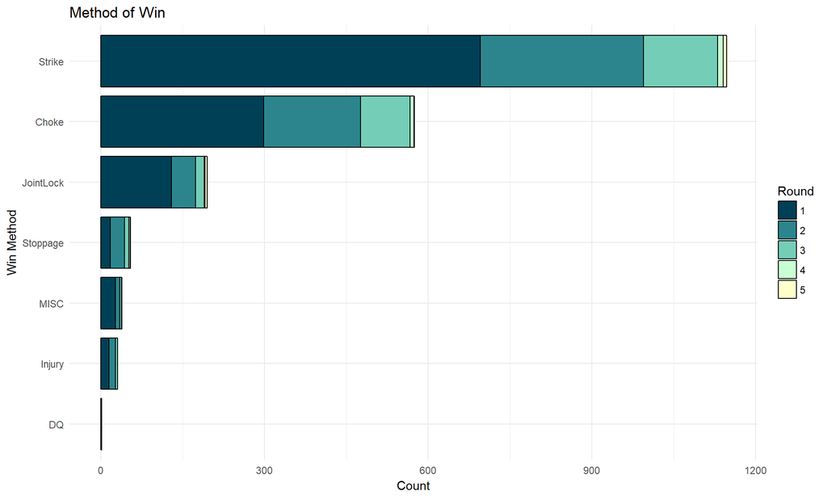

| Category | 1 | 2 | 3 | 4 | 5 |
| --- | --- | --- | --- | --- | --- |
| Strike | 696 | 299 | 136 | 10 | 6 |
| Choke | 299 | 177 | 91 | 7 | 1 |
| JointLock | 130 | 44 | 16 | 1 | 4 |
| Stoppage | 18 | 26 | 8 | 2 | 1 |
| MISC | 27 | 8 | 3 | 1 | 0 |
| Injury | 15 | 12 | 4 | 0 | 0 |
| DQ | 1 | 0 | 1 | 0 | 0 |

## Fight Like a Girl: Do gender differences exist in how MMA fights are won?

There were 3,445 men’s MMA fight and 102 women’s MMA fights in the dataset. Due to the large disparty between the two, the analysis of finishes required percentages rather than raw numbers.

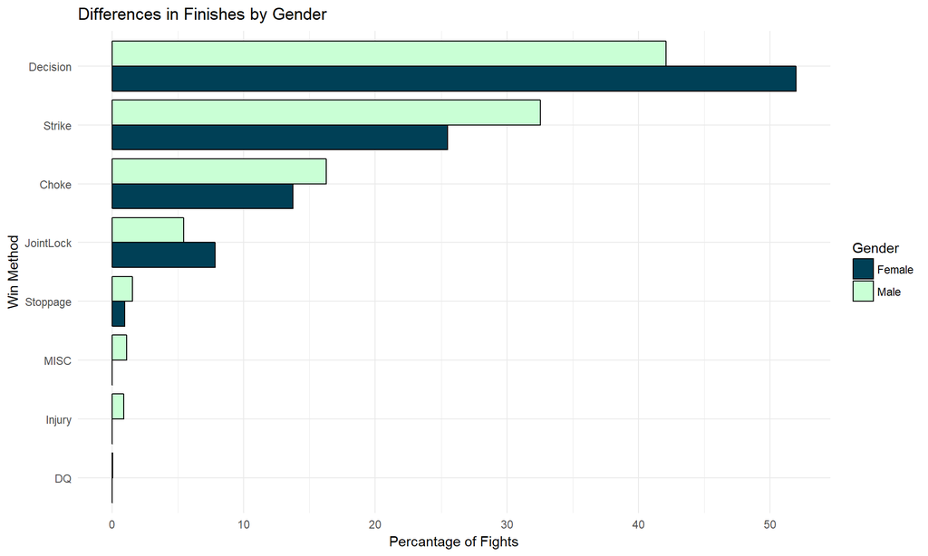

| Gender | Decision | Strike | Choke | JointLock | Stoppage | MISC | Injury | DQ |
| --- | --- | --- | --- | --- | --- | --- | --- | --- |
| Female | 51.96 | 25.49 | 13.73 | 7.84 | 0.98 | 0.00 | 0.0 | 0.00 |
| Male | 42.09 | 32.54 | 16.28 | 5.43 | 1.57 | 1.13 | 0.9 | 0.06 |

## Differences in decision wins by gender

Overall, men’s fights end in unanimous decisions more often in unianimous decisions, whereby all three judges score the fight in favor of one fighter. On the other hand, women’s fights end slightly more often in split or majority decisions, whereby two judges score the fight for the winning fighter while the third judge scores it for the losing fighter (split decision) or as a draw (majority decision).

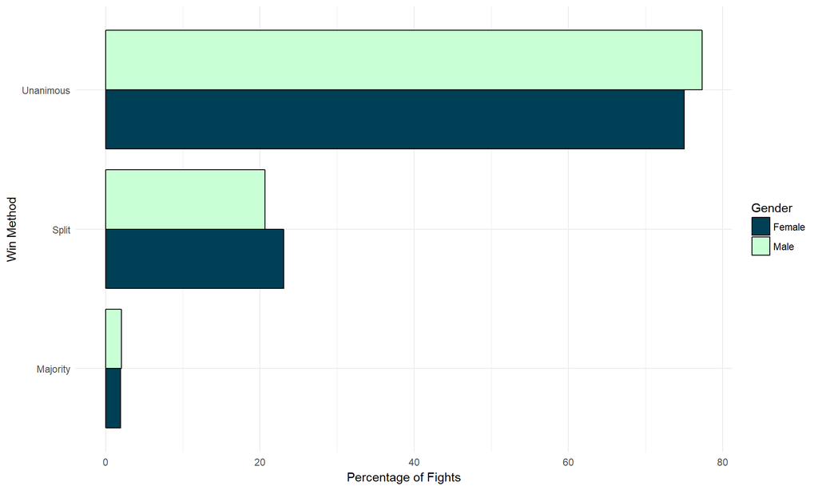

| Gender | Unanimous | Split | Majority |
| --- | --- | --- | --- |
| Female | 75.0 | 23.08 | 1.92 |
| Male | 77.3 | 20.67 | 2.03 |

## Is Ring Rust Real?:

Partially exaggerate, partially misunderstood, or partially true?

The graph below shows the average time fighters took between fights, and whether the fighter won his/her fight. Fighters who took longer between fights were statistically more likely to lose their next fight (p-value < 0.05).

Despite the statistical significance, there is only a miniscule difference in average time between wins and losses (~3 weeks) and a relatively low variability (standard error) in both groups. Therefore, I would not conclude an additional three weeks of rest between fights will make or break a fight!

Fighters that fought multiple times in a single event were excluded. Statistical significance was determined using a two-sample Student’s t-test.

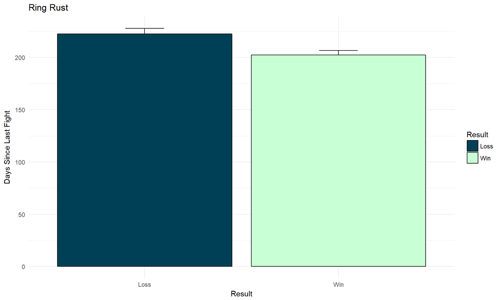

| Loss: Mean Days | Win: Mean Days | P-value |
| --- | --- | --- |
| 222.4218 | 202.2848 | 3.38e-03 |

## Is There a Hometown Advantage in MMA?

Whether it’s psychological or physical, fights that take place in a fighter’s home state are more likely to go in their favor. (Hometown: 57%, Away: 50%)

Hometowns were determined by the city that the fighter currently fights and trains out of, rather than their birthplace.

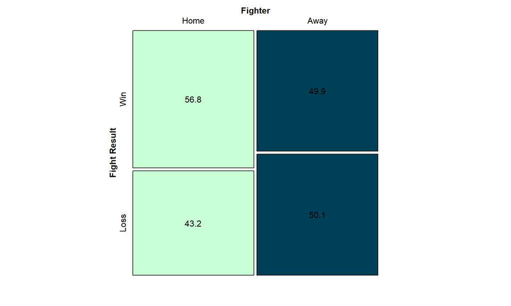

|  | Win | Loss |
| --- | --- | --- |
| Home | 56.8 | 43.2 |
| Away | 49.9 | 50.1 |

## The Land of Savages: Where do most UFC fighters come from?

A quick overview of fighters locality in the UFC. Due to the large disparity in numbers between fighters on the UFC roster from the US compared to other countries, the two groups were examined individually.

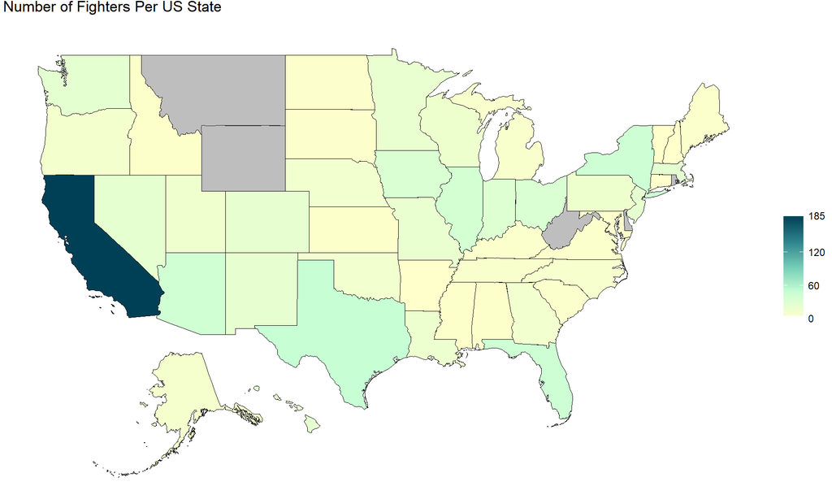

Top 10 States with most UFC Fighters

| State | Number of Fighters |
| --- | --- |
| California | 185 |
| Texas | 48 |
| Florida | 43 |
| New York | 43 |
| Arizona | 41 |
| Illinois | 39 |
| Ohio | 34 |
| Iowa | 33 |
| Indiana | 31 |
| Massachusetts | 25 |

```
FALSE 58 codes from your data successfully matched countries in the map
FALSE 6 codes from your data failed to match with a country code in the map
FALSE 186 codes from the map weren't represented in your data
```

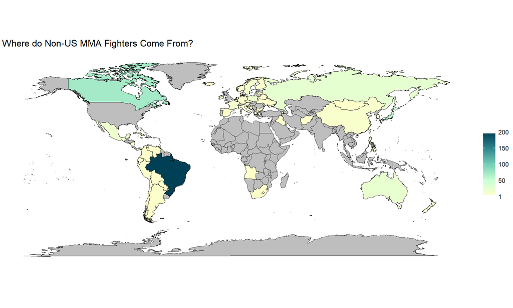

Top 10 Countries with most UFC Fighters (Excluding USA)

| Country | Number of Fighters |
| --- | --- |
| Brazil | 199 |
| Canada | 72 |
| United Kingdom | 61 |
| Japan | 55 |
| Russia | 25 |
| Australia | 23 |
| Mexico | 17 |
| Poland | 17 |
| Sweden | 15 |
| Netherlands | 14 |

# Supplementary Data

### Wins by Strikes

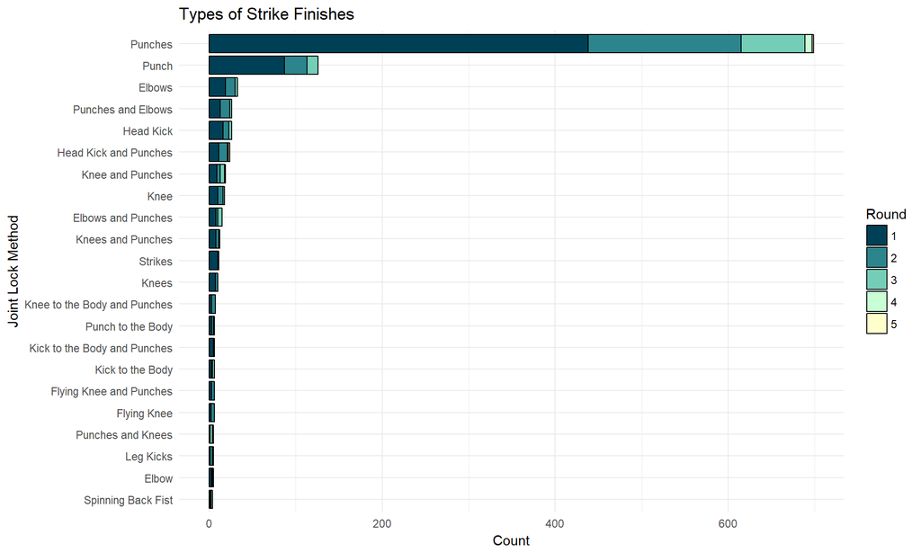

| Strikes | Count |
| --- | --- |
| Punches | 699 |
| Punch | 126 |
| Elbows | 33 |
| Head Kick | 26 |
| Punches and Elbows | 26 |
| Head Kick and Punches | 24 |
| Knee and Punches | 19 |
| Knee | 18 |
| Elbows and Punches | 15 |
| Knees and Punches | 12 |
| Strikes | 11 |
| Knees | 10 |
| Knee to the Body and Punches | 7 |
| Flying Knee | 6 |
| Flying Knee and Punches | 6 |
| Kick to the Body | 6 |
| Kick to the Body and Punches | 6 |
| Punch to the Body | 6 |
| Elbow | 5 |
| Leg Kicks | 5 |
| Punches and Knees | 5 |
| Spinning Back Fist | 4 |

### Wins by Choke

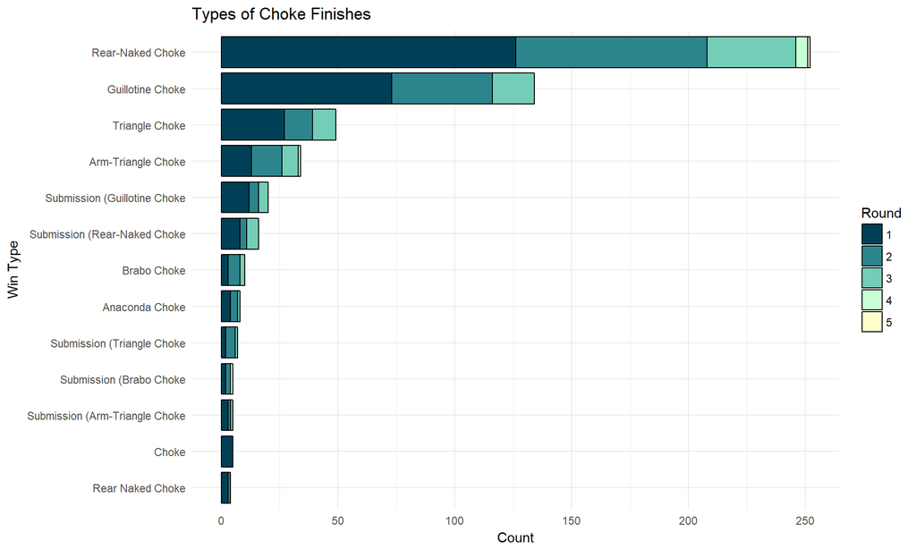

| Choke | Count |
| --- | --- |
| Rear-Naked Choke | 252 |
| Guillotine Choke | 134 |
| Triangle Choke | 49 |
| Arm-Triangle Choke | 34 |
| Submission (Guillotine Choke | 20 |
| Submission (Rear-Naked Choke | 16 |
| Brabo Choke | 10 |
| Anaconda Choke | 8 |
| Submission (Triangle Choke | 7 |
| Choke | 5 |
| Submission (Arm-Triangle Choke | 5 |
| Submission (Brabo Choke | 5 |
| Rear Naked Choke | 4 |

### Wins by Joint Lock

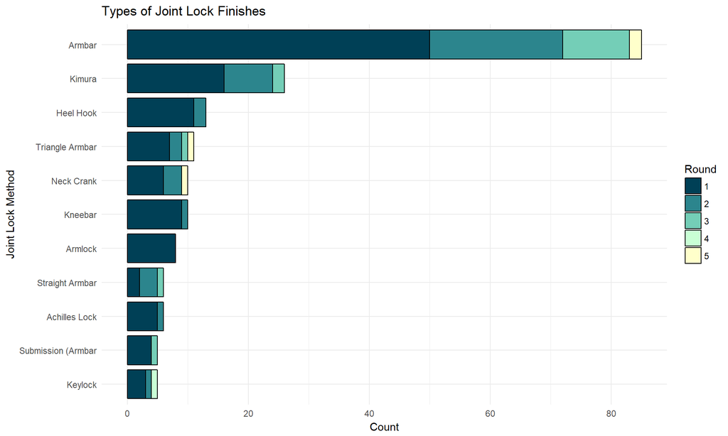

| Joint Lock | Count |
| --- | --- |
| Armbar | 85 |
| Kimura | 26 |
| Heel Hook | 13 |
| Triangle Armbar | 11 |
| Kneebar | 10 |
| Neck Crank | 10 |
| Armlock | 8 |
| Achilles Lock | 6 |
| Straight Armbar | 6 |
| Keylock | 5 |
| Submission (Armbar | 5 |

### Wins by Stoppage

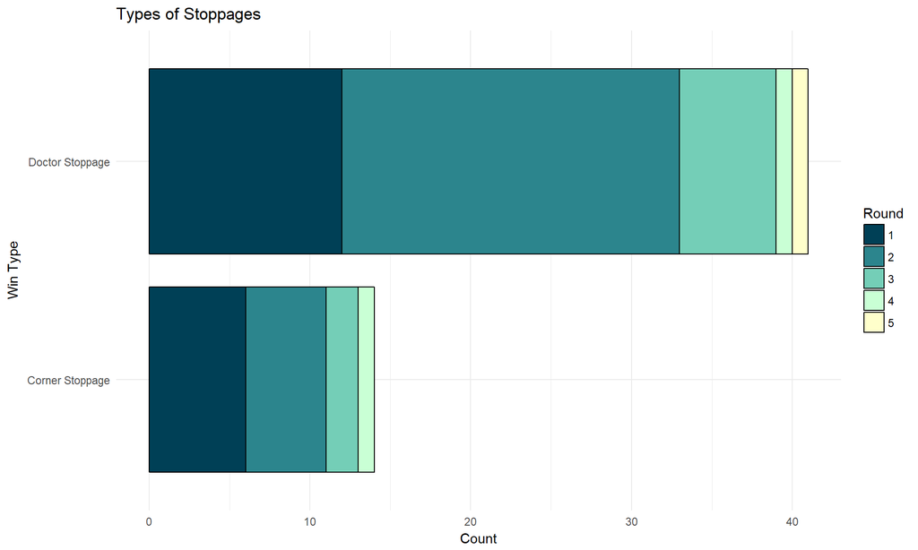

| Stoppage | Count |
| --- | --- |
| Doctor Stoppage | 41 |
| Corner Stoppage | 14 |

### Wins by Miscellaneous Methods

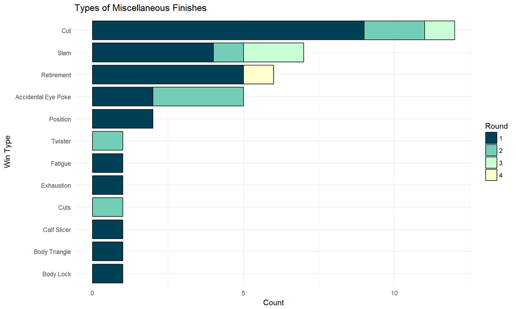

| Misc Finish | Count |
| --- | --- |
| Cut | 12 |
| Slam | 7 |
| Retirement | 6 |
| Accidental Eye Poke | 5 |
| Position | 2 |
| Body Lock | 1 |
| Body Triangle | 1 |
| Calf Slicer | 1 |
| Cuts | 1 |
| Exhaustion | 1 |
| Fatigue | 1 |
| Twister | 1 |

### Wins by Injury

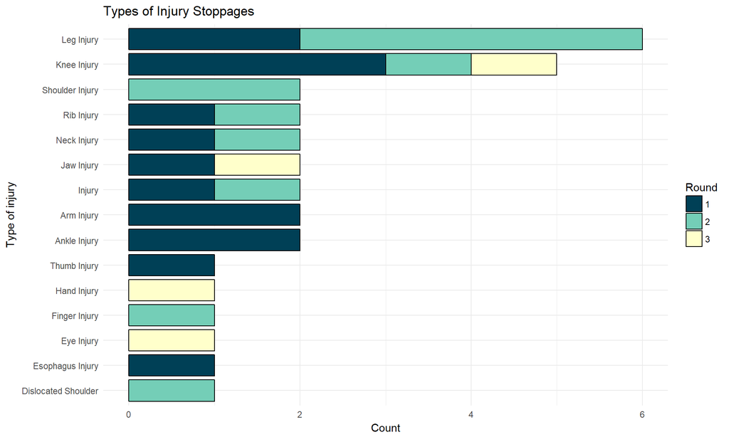

| Injury | Count |
| --- | --- |
| Leg Injury | 6 |
| Knee Injury | 5 |
| Ankle Injury | 2 |
| Arm Injury | 2 |
| Injury | 2 |
| Jaw Injury | 2 |
| Neck Injury | 2 |
| Rib Injury | 2 |
| Shoulder Injury | 2 |
| Dislocated Shoulder | 1 |
| Esophagus Injury | 1 |
| Eye Injury | 1 |
| Finger Injury | 1 |
| Hand Injury | 1 |
| Thumb Injury | 1 |